# Supplement_BI

Daniel T. Citron

10/17/2018

```r
## Setup for creating maps:
# Read in shape files of Bioko Island and the area-level grid
bioko<-readOGR("/Users/dtcitron/Documents/MASH/MASH-Main/MASH-dev/DanielCitron/Bioko_Island_Cluster_Simulations/BI_maps/bioko", "bioko_admin1")
areas_inh<-readOGR("/Users/dtcitron/Documents/MASH/MASH-Main/MASH-dev/DanielCitron/Bioko_Island_Cluster_Simulations/BI_maps/areas_inh", "areas_inh")
areasf<-fortify(areas_inh, region = "areaId")
```

Set working directory:

```r
setwd("/Users/dtcitron/Documents/MASH/Bioko_Macro/Travel_Model_Fitting/Importations - Carlos Paper")
```

Read in data:

```r
BI <- as.data.table(read.csv("/Users/dtcitron/Documents/MASH/Bioko_Macro/Travel_Model_Fitting/Importations - Carlos Paper/eta.csv"))
denom <- data.table(read.csv("/Users/dtcitron/Documents/MASH/MASH-Main/MASH-dev/DanielCitron/Bioko_Island_Cluster_Simulations/BI_sim_setup_data/bioko_areas.csv"))

BI <- merge(BI, denom[, c("areaId", "pop")], by = "areaId")

pop.total <- sum(BI$pop)
```

# Define functions for co-estimation

- The function `Travel2PR` calcualtes $PR=(h+\eta \delta)/(h+\eta \delta+r)$
- The function `Travel2h` co-estimates `h` and `eta` (and outputs `h` only), and does this by minimizing the difference between PR and $(h+\eta \delta)/(h+\eta \delta+r)$. Note that this does not always result in an exact solution, but we’ll get as close as we can.
- The function `Travel2eta` estimates `eta`. Note that `h` defaults to 0, but that if we plug in `h` using the results from `Travel2h` we get the co-estimated value for `eta`. Note also that `eta` $\propto$ the difference between prevalence among travelers and the local residual transmission - we can only use this to calculate our co-estimate, not either the upper or lower bounds
- The function `Travel2TF` estimates the travel fraction once `eta` is known

```r
# Solve for PR, based on delta, eta, h
Travel2PR = function(Xt, Xp, h=0, T=56, r=1/200, eta=NULL){
  if(is.null(eta)) eta = Travel2eta(Xt, Xp, h, T, r)
  delta = -log(1-Xt)/T
  return((eta*delta + h)/(eta*delta + h + r))
}

Travel2h=function(Xt, Xp, PR, T=56, r=1/200, hmx = 3/365, eta=NULL){
  geth = function(h){
    abs(PR - Travel2PR(Xt, Xp, h, T, r, eta))^2#^(1/2)
  }
  optimize(geth, c(0,hmx))$min
}

# Once h is known, need to back solve for eta, this time using PR_L0 = h/(h + r)
Travel2eta = function(Xt, Xp, h=0, T=56, r=1/200){
  # Xt :: period prevalence for travel in the last 56 days
  # Xp :: reported prevalence in travelers
  LR = h/(h+r) # Local residual PR - equilibrium value when there are no importations
  prt = function(t){exp(-r*t)}
  return(T*pmax(Xp-LR,0)/integrate(prt, 0, T)$val) #eta
}

# Travel Fraction - need eta
Travel2TF = function(Xt, Xp, PR, h=0, T=56, r=1/200, eta=NULL){
  tpr = Travel2PR(Xt, Xp, 0, T, r, eta)
  pmin(tpr/PR, 1)
}
```

# Figure: Rate of travel This figure is optional

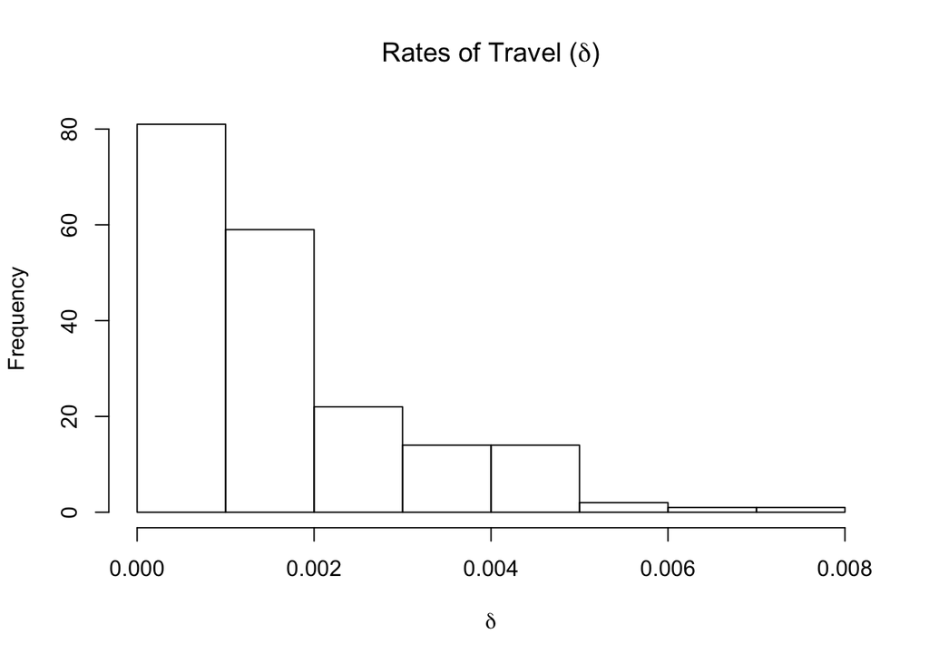

```r
BI$delta <- 0

BI$delta <- -log(1 - BI$to_map)/56

hist(BI$delta, main = TeX("Rates of Travel $(\\delta)$"), xlab = TeX("$\\delta$"))
```

# Setup: define r

```r
r = 1/200
```

# Upper bound, lower bound, and coestimated values for `eta` and `delta`

```r
# upper
BI$eta.upper <- pmax((BI$prt_map),0)*56*r/(1 - exp(-56*r))
BI$h.upper <- 0
for (i in 1:194){
  BI$h.upper[[i]] <- Travel2h(BI$to_map[[i]], BI$prt_map[[i]], BI$prall_map[[i]], eta = BI$eta.upper[[i]])
}
# lower
BI$eta.lower <- pmax((BI$prt_map-BI$prall_map),0)*56*r/(1 - exp(-56*r))
BI$h.lower <- 0
for (i in 1:194){
  BI$h.lower[[i]] <- Travel2h(BI$to_map[[i]], BI$prt_map[[i]], BI$prall_map[[i]], eta = BI$eta.lower[[i]])
}
# coestimate
BI$h.co <- 0
for (i in 1:194){
  BI$h.co[[i]] <- Travel2h(BI$to_map[[i]], BI$prt_map[[i]], BI$prall_map[[i]])
}
BI$eta.co <- 0
for (i in 1:194){
  BI$eta.co[[i]] <- Travel2eta(BI$to_map[[i]], BI$prt_map[[i]], h = BI$h.co[[i]])
}
```

# Upper bound, lower bound, and coestimated values for travel fraction

```r
# Coestimate TF
BI$tf.co = rep(0, 194)
for (i in 1:194){
  BI$tf.co[[i]] = Travel2TF(BI$to_map[[i]], BI$prt_map[[i]], BI$prall_map[[i]], eta=BI$eta.co[[i]])
}
# Upper TF
BI$tf.upper <- with(BI, pmin((eta.upper*delta)/(eta.upper*delta + 1/200)/prall_map,1))
# Lower TF
BI$tf.lower <- with(BI, pmin((eta.lower*delta)/(eta.lower*delta + 1/200)/prall_map,1))
```

# Generate Figures

## Figure: TF maps - coestimate, upper, lower

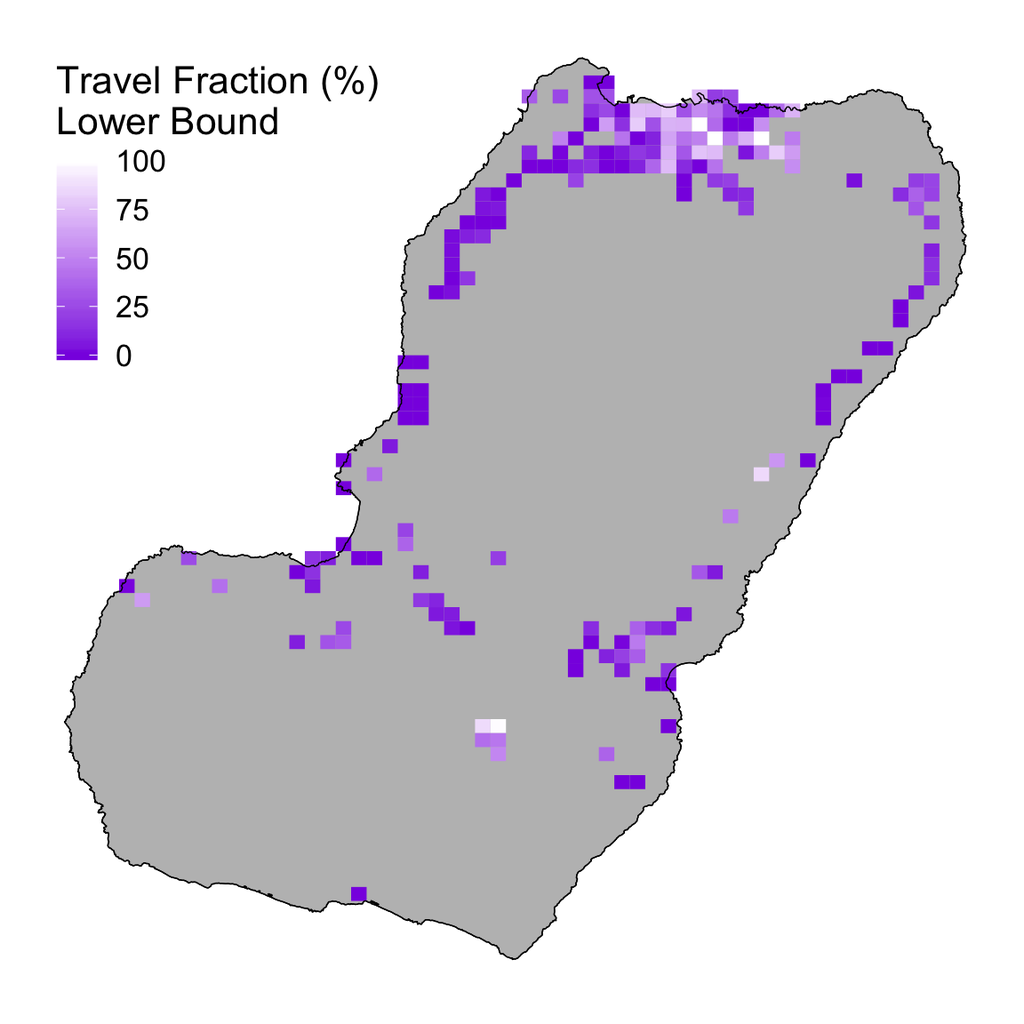

```r
area.data = merge(areasf, BI, by.x = "id", by.y = "areaId", all=TRUE)
plot.data<-area.data[order(area.data$order), ]
p1 = ggplot(data = plot.data, aes(x=long, y=lat, group = group))
p2 = p1 + geom_polygon(data = bioko, aes(x = long, y = lat, group = group), color = "black", fill="grey", size = 0.25)
tf.lower.map <- p2 + geom_polygon(data = plot.data, aes(x = long, y = lat, group = group, fill = 100*tf.lower), color = NA, size = 0.25) +
  scale_fill_gradient(name="Travel Fraction (%)\nLower Bound", low="blueviolet", high="white", limits=c(0, 100)) +
  geom_polygon(data = bioko, aes(x = long, y = lat, group = group), color = "black", fill=NA, size = 0.25) +
  theme(text = element_text(size = 16),
        axis.line=element_blank(), axis.text.x=element_blank(),
        axis.text.y=element_blank(),axis.ticks=element_blank(),
        axis.title.x=element_blank(),
        axis.title.y=element_blank(), panel.background=element_blank(), legend.position=c(0.2, 0.8))
tf.lower.map
```

```r
#ggsave("tf_lower_map.pdf", plot = tf.lower.map)
```

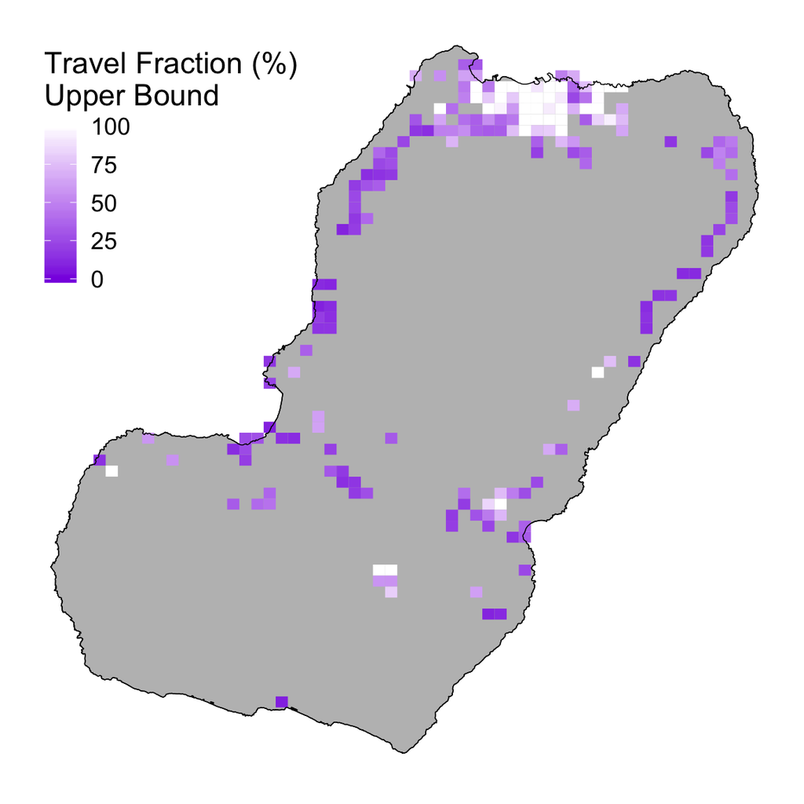

```r
tf.upper.map <- p2 + geom_polygon(data = plot.data, aes(x = long, y = lat, group = group, fill = 100*tf.upper), color = NA, size = 0.25) +
  scale_fill_gradient(name="Travel Fraction (%)\nUpper Bound", low="blueviolet", high="white", limits=c(0, 100)) +
  geom_polygon(data = bioko, aes(x = long, y = lat, group = group), color = "black", fill=NA, size = 0.25) +
  theme(text = element_text(size = 16),
        axis.line=element_blank(), axis.text.x=element_blank(),
        axis.text.y=element_blank(),axis.ticks=element_blank(),
        axis.title.x=element_blank(),
        axis.title.y=element_blank(), panel.background=element_blank(), legend.position=c(0.2, 0.8))
tf.upper.map
```

```r
#ggsave("tf_upper_map.pdf", plot = tf.upper.map)
```

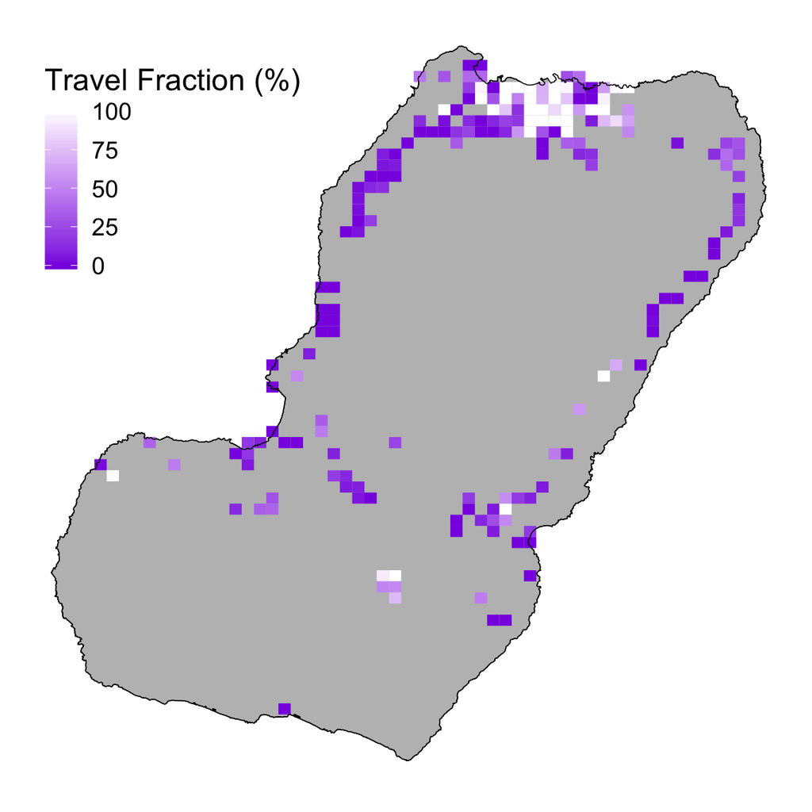

```r
tf.co.map <- p2 + geom_polygon(data = plot.data, aes(x = long, y = lat, group = group, fill = 100*tf.co), color = NA, size = 0.25) +
  scale_fill_gradient(name="Travel Fraction (%)", low="blueviolet", high="white", limits=c(0, 100)) +
  geom_polygon(data = bioko, aes(x = long, y = lat, group = group), color = "black", fill=NA, size = 0.25) +
  theme(text = element_text(size = 16),
        axis.line=element_blank(), axis.text.x=element_blank(),
        axis.text.y=element_blank(),axis.ticks=element_blank(),
        axis.title.x=element_blank(),
        axis.title.y=element_blank(), panel.background=element_blank(), legend.position=c(0.2, 0.8))
tf.co.map
```

```r
#ggsave("tf_co_map.pdf", plot = tf.co.map)
```

## Figure: LR maps - coestimate, upper, lower

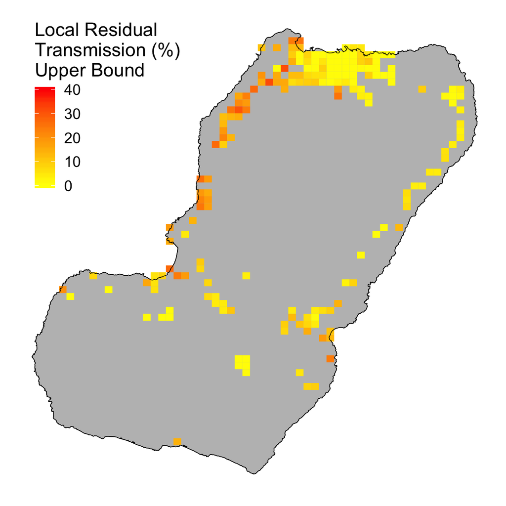

```r
h.upper.map <- p2 + geom_polygon(data = plot.data, aes(x = long, y = lat, group = group, fill = 100*h.upper/(h.upper+1/200)), color = NA, size = 0.25) +
  scale_fill_gradient(name="Local Residual\nTransmission (%)\nUpper Bound",
                      low="yellow", high="red", limits=c(0, 40)) +
  geom_polygon(data = bioko, aes(x = long, y = lat, group = group), color = "black", fill=NA, size = 0.25) +
  theme(text = element_text(size = 16),
        axis.line=element_blank(), axis.text.x=element_blank(),
        axis.text.y=element_blank(),axis.ticks=element_blank(),
        axis.title.x=element_blank(),
        axis.title.y=element_blank(), panel.background=element_blank(), legend.position=c(0.2, 0.8))
h.upper.map
```

```r
#ggsave("h_upper_map.pdf", plot = h.upper.map)
```

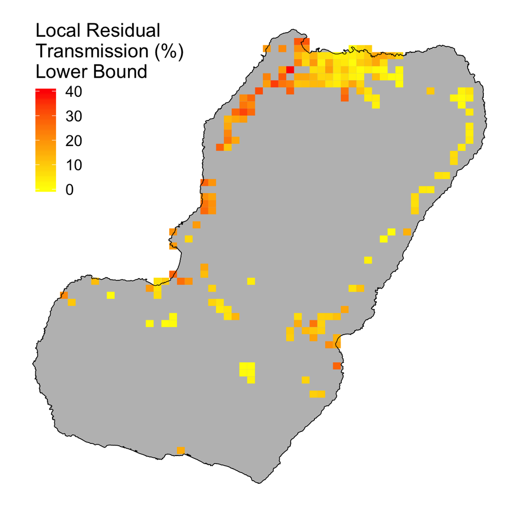

```r
h.lower.map <- p2 + geom_polygon(data = plot.data, aes(x = long, y = lat, group = group, fill = 100*h.lower/(h.lower+1/200)), color = NA, size = 0.25) +
  scale_fill_gradient(name="Local Residual\nTransmission (%)\nLower Bound",
                      low="yellow", high="red", limits=c(0, 40)) +
  geom_polygon(data = bioko, aes(x = long, y = lat, group = group), color = "black", fill=NA, size = 0.25) +
  theme(text = element_text(size = 16),
        axis.line=element_blank(), axis.text.x=element_blank(),
        axis.text.y=element_blank(),axis.ticks=element_blank(),
        axis.title.x=element_blank(),
        axis.title.y=element_blank(), panel.background=element_blank(), legend.position=c(0.2, 0.8))
h.lower.map
```

```r
#ggsave("h_lower_map.pdf", plot = h.lower.map)
```

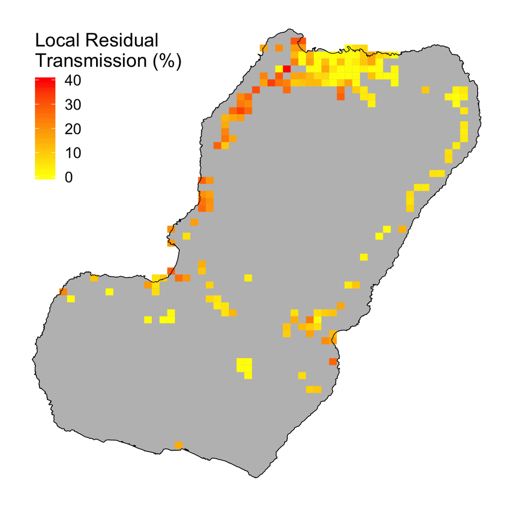

```r
h.co.map <- p2 + geom_polygon(data = plot.data, aes(x = long, y = lat, group = group, fill = 100*h.co/(h.co+1/200)), color = NA, size = 0.25) +
  scale_fill_gradient(name="Local Residual\nTransmission (%)",
                      low="yellow", high="red", limits=c(0, 40)) +
  geom_polygon(data = bioko, aes(x = long, y = lat, group = group), color = "black", fill=NA, size = 0.25) +
  theme(text = element_text(size = 16),
        axis.line=element_blank(), axis.text.x=element_blank(),
        axis.text.y=element_blank(),axis.ticks=element_blank(),
        axis.title.x=element_blank(),
        axis.title.y=element_blank(), panel.background=element_blank(), legend.position=c(0.2, 0.8))
h.co.map
```

```r
#ggsave("h_co_map.pdf", plot = h.co.map)
```

(Save plots)

```r
ggsave("tf_lower_map.pdf", plot = tf.lower.map)
ggsave("tf_upper_map.pdf", plot = tf.upper.map)
ggsave("tf_co_map.pdf", plot = tf.co.map)

ggsave("h_upper_map.pdf", plot = h.upper.map)
ggsave("h_lower_map.pdf", plot = h.lower.map)
ggsave("h_co_map.pdf", plot = h.co.map)
```

## Generate Tables

```r
# Coestimate
print("Coestimate")
```

```
## [1] "Coestimate"
```

```r
c(sum(BI[tf.co >= 1]$pop)/pop.total, sum(BI[tf.co >= 0.8]$pop)/pop.total, sum(BI[tf.co >= 0.5]$pop)/pop.total)
```

```
## [1] 0.3797212 0.5193494 0.7222616
```

```r
# Upper
print("Upper")
```

```
## [1] "Upper"
```

```r
c(sum(BI[tf.upper >= 1]$pop)/pop.total, sum(BI[tf.upper >= 0.8]$pop)/pop.total, sum(BI[tf.upper >= 0.5]$pop)/pop.total)
```

```
## [1] 0.5357734 0.6972250 0.7797212
```

```r
# Lower
print("Lower")
```

```
## [1] "Lower"
```

```r
c(sum(BI[tf.lower >= 1]$pop)/pop.total, sum(BI[tf.lower >= 0.8]$pop)/pop.total, sum(BI[tf.lower >= 0.5]$pop)/pop.total)
```

```
## [1] 0.09985395 0.10741314 0.40901527
```

## Figure: eta histograms

This figure is optional

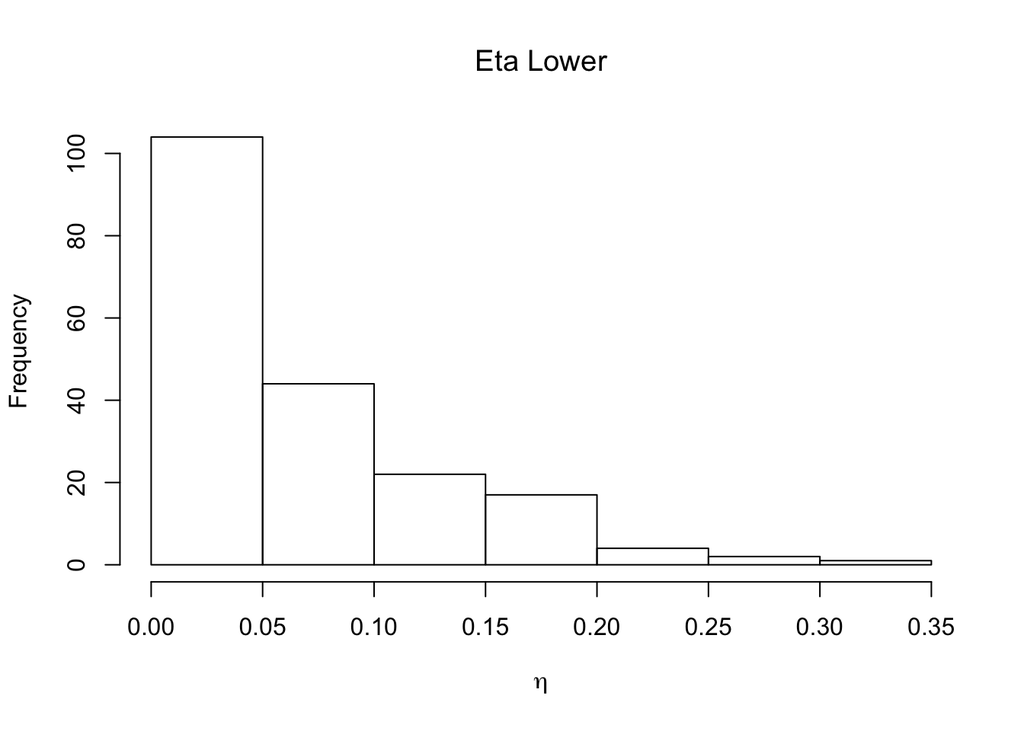

```r
hist(BI$eta.lower, main = TeX("Eta Lower"), xlab = TeX("$\\eta$"))
```

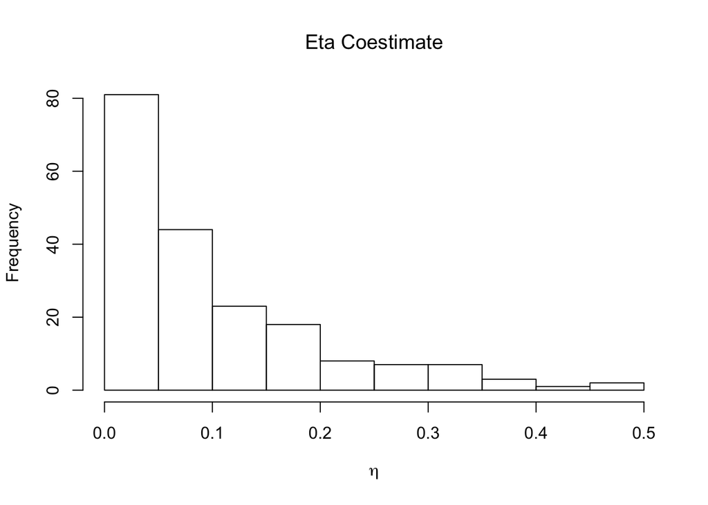

```r
hist(BI$eta.co, main = TeX("Eta Coestimate$"), xlab = TeX("$\\eta$"))
```

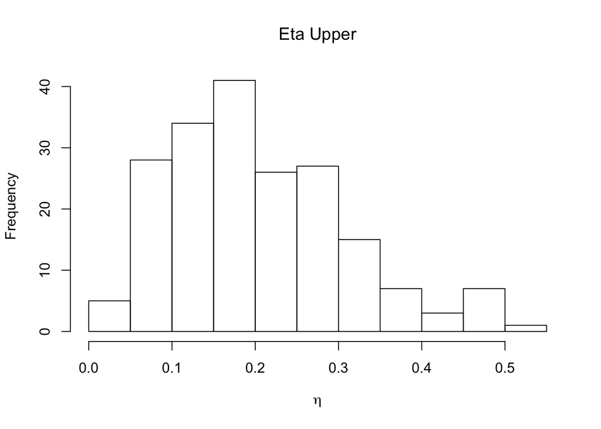

```r
hist(BI$eta.upper, main = TeX("Eta Upper"), xlab = TeX("$\\eta$"))
```

## Figure: Travel Fraction Histograms

First, solve for local FOI

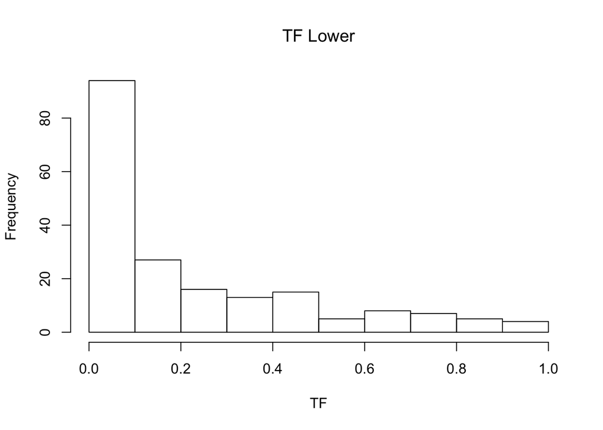

```r
hist(BI$tf.lower, main = TeX("TF Lower"), xlab = TeX("$\\TF$"))
```

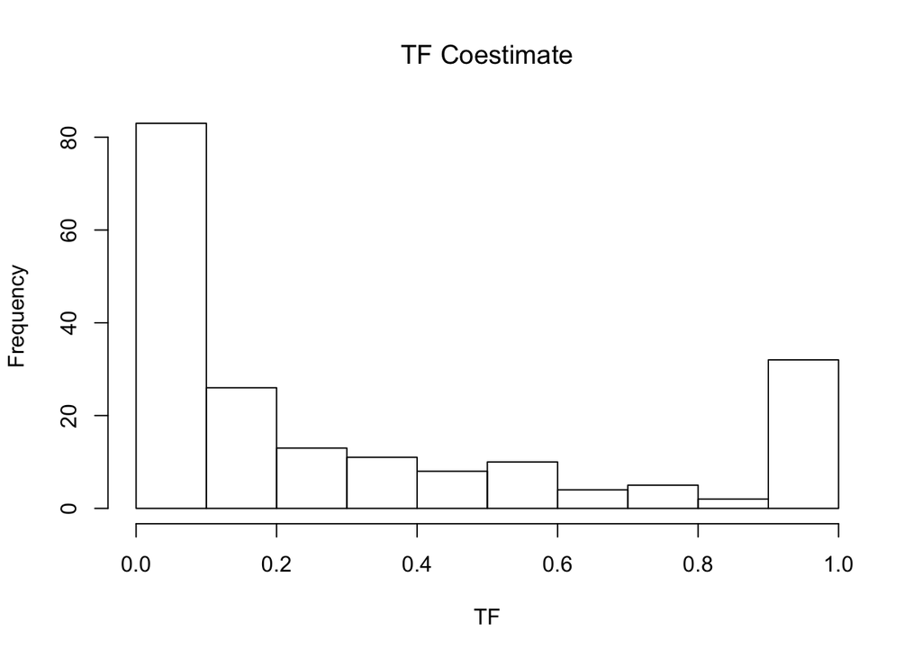

```r
hist(BI$tf.co, main = TeX("TF Coestimate$"), xlab = TeX("$\\TF$"))
```

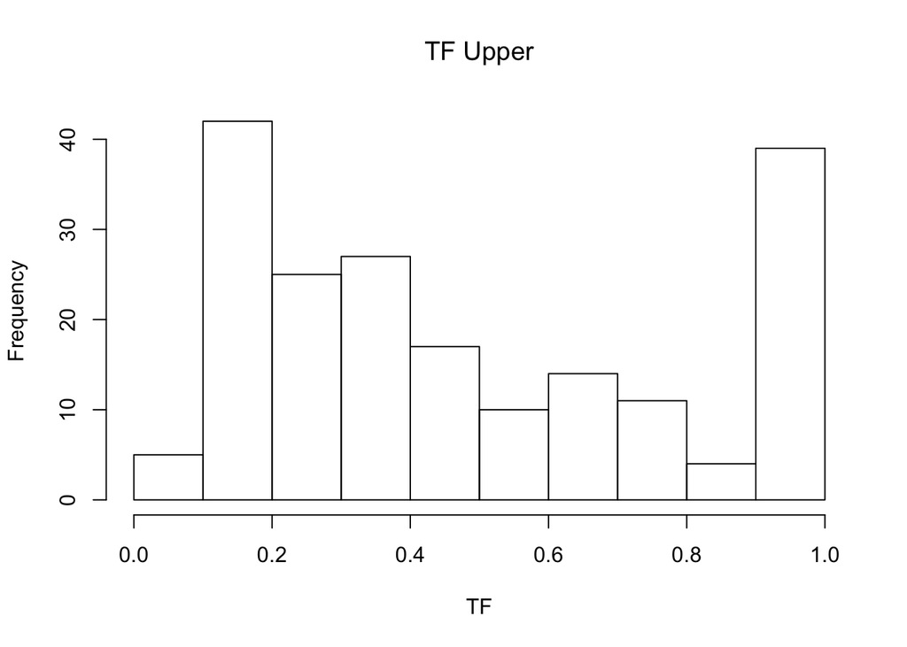

```r
hist(BI$tf.upper, main = TeX("TF Upper"), xlab = TeX("$\\TF$"))
```

# Repeating analysis, but this time using travel to EG only

Denote all variables with this change using .e at the end

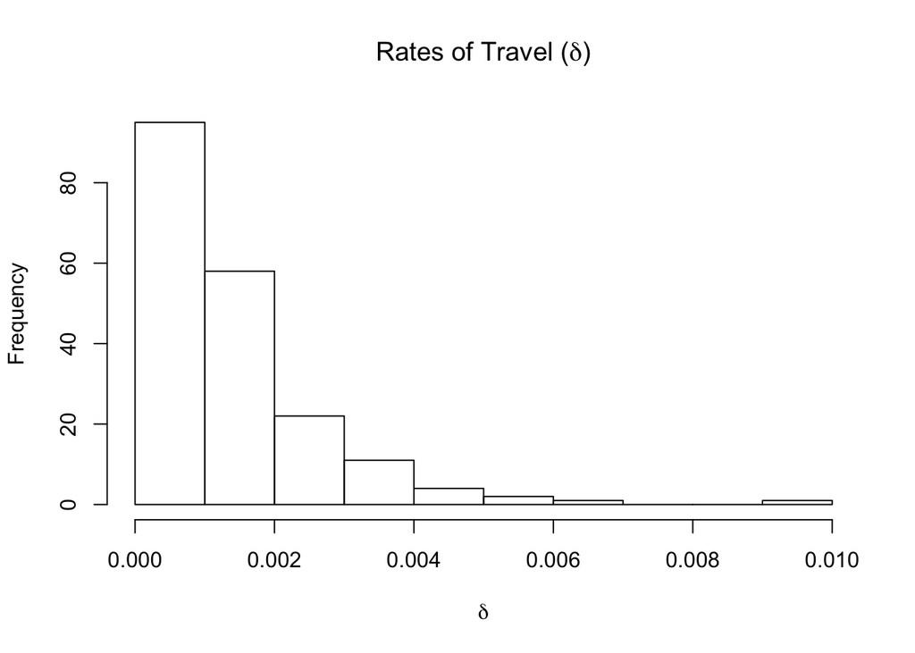

```r
BI$delta.e <- 0

BI$delta.e <- -log(1 - BI$te_map)/56

hist(BI$delta.e, main = TeX("Rates of Travel $(\\delta)$"), xlab = TeX("$\\delta$"))
```

## Upper bound, lower bound, and coestimated values for `eta` and `delta`

```r
# upper
BI$eta.upper.e <- pmax((BI$pre_map),0)*56*r/(1 - exp(-56*r))
BI$h.upper.e <- 0
for (i in 1:194){
  BI$h.upper.e[[i]] <- Travel2h(BI$te_map[[i]], BI$pre_map[[i]], BI$prall_map[[i]], eta = BI$eta.upper.e[[i]])
}
# lower
BI$eta.lower.e <- pmax((BI$pre_map-BI$prall_map),0)*56*r/(1 - exp(-56*r))
BI$h.lower.e <- 0
for (i in 1:194){
  BI$h.lower.e[[i]] <- Travel2h(BI$te_map[[i]], BI$pre_map[[i]], BI$prall_map[[i]], eta = BI$eta.lower.e[[i]])
}
# coestimate
BI$h.co.e <- 0
for (i in 1:194){
  BI$h.co.e[[i]] <- Travel2h(BI$te_map[[i]], BI$pre_map[[i]], BI$prall_map[[i]])
}
BI$eta.co.e <- 0
for (i in 1:194){
  BI$eta.co.e[[i]] <- Travel2eta(BI$te_map[[i]], BI$pre_map[[i]], h = BI$h.co.e[[i]])
}
```

## Upper bound, lower bound, and coestimated values for travel fraction

```r
# Coestimate TF
BI$tf.co.e = rep(0, 194)
for (i in 1:194){
  BI$tf.co.e[[i]] = Travel2TF(BI$te_map[[i]], BI$pre_map[[i]], BI$prall_map[[i]], eta=BI$eta.co.e[[i]])
}
# Upper TF
BI$tf.upper.e <- with(BI, pmin((eta.upper.e*delta.e)/(eta.upper.e*delta.e + 1/200)/prall_map,1))
# Lower TF
BI$tf.lower.e <- with(BI, pmin((eta.lower.e*delta.e)/(eta.lower.e*delta.e + 1/200)/prall_map,1))
```

## Generate figures

### Figure: TF maps - coestimate, upper, lower

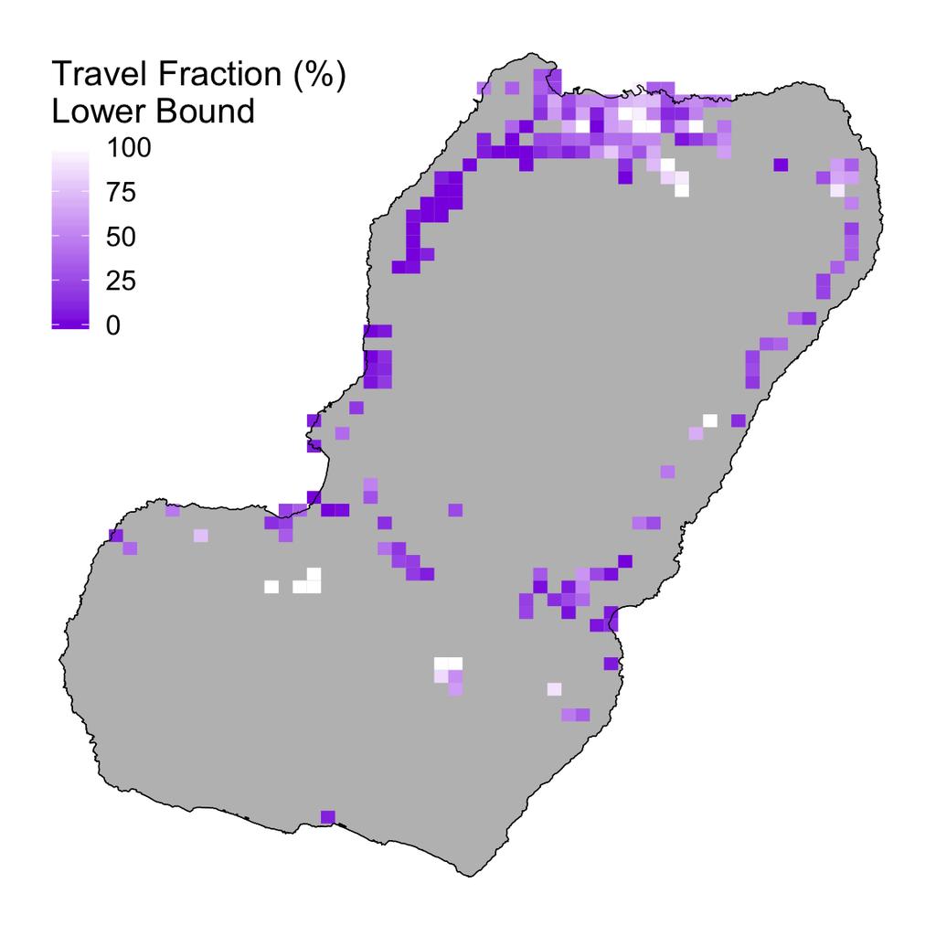

```r
area.data = merge(areasf, BI, by.x = "id", by.y = "areaId", all=TRUE)
plot.data<-area.data[order(area.data$order), ]
p1 = ggplot(data = plot.data, aes(x=long, y=lat, group = group))
p2 = p1 + geom_polygon(data = bioko, aes(x = long, y = lat, group = group), color = "black", fill="grey", size = 0.25)
tf.lower.map.e <- p2 + geom_polygon(data = plot.data, aes(x = long, y = lat, group = group, fill = 100*tf.lower.e), color = NA, size = 0.25) +
  scale_fill_gradient(name="Travel Fraction (%)\nLower Bound", low="blueviolet", high="white", limits=c(0, 100)) +
  geom_polygon(data = bioko, aes(x = long, y = lat, group = group), color = "black", fill=NA, size = 0.25) +
  theme(text = element_text(size = 16),
        axis.line=element_blank(), axis.text.x=element_blank(),
        axis.text.y=element_blank(),axis.ticks=element_blank(),
        axis.title.x=element_blank(),
        axis.title.y=element_blank(), panel.background=element_blank(), legend.position=c(0.2, 0.8))
tf.lower.map.e
```

```r
#ggsave("tf_lower_map_e.pdf", plot = tf.lower.map.e)
```

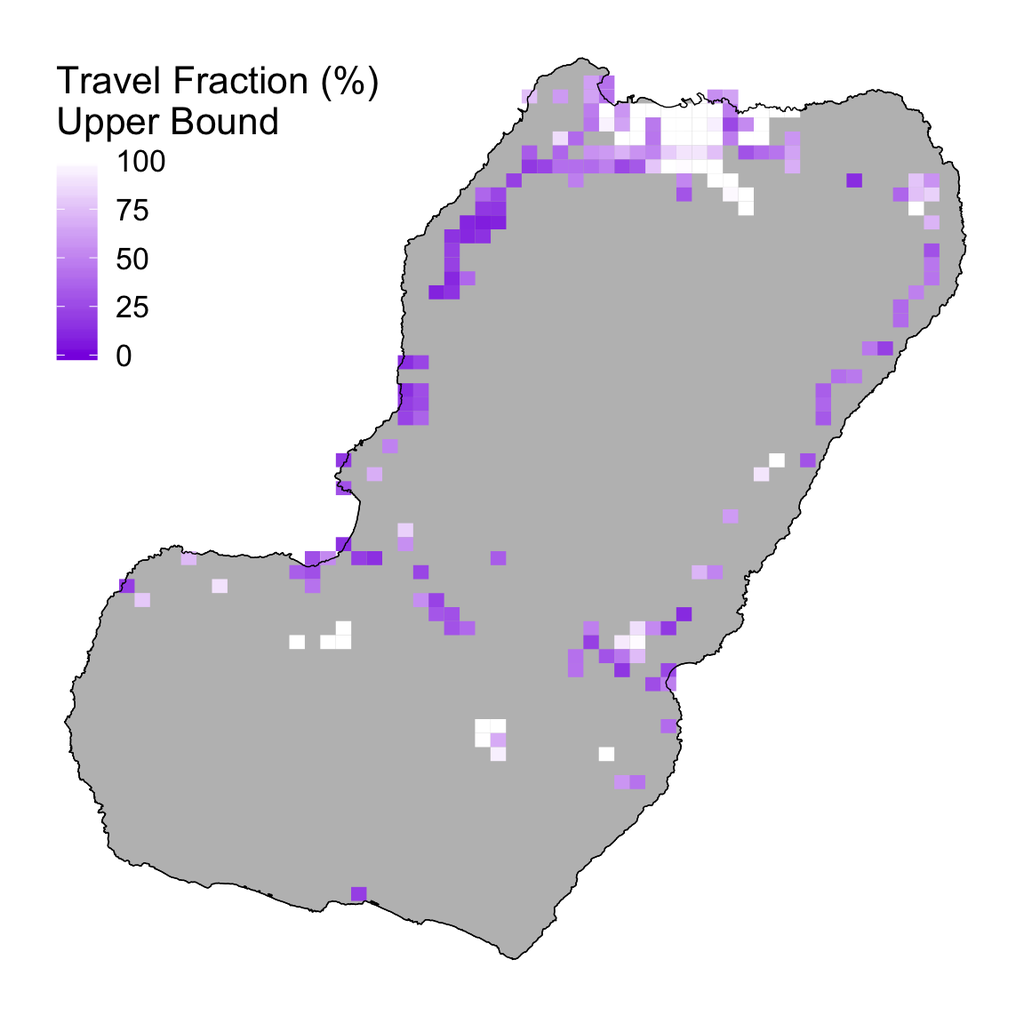

```r
tf.upper.map.e <- p2 + geom_polygon(data = plot.data, aes(x = long, y = lat, group = group, fill = 100*tf.upper.e), color = NA, size = 0.25) +
  scale_fill_gradient(name="Travel Fraction (%)\nUpper Bound", low="blueviolet", high="white", limits=c(0, 100)) +
  geom_polygon(data = bioko, aes(x = long, y = lat, group = group), color = "black", fill=NA, size = 0.25) +
  theme(text = element_text(size = 16),
        axis.line=element_blank(), axis.text.x=element_blank(),
        axis.text.y=element_blank(),axis.ticks=element_blank(),
        axis.title.x=element_blank(),
        axis.title.y=element_blank(), panel.background=element_blank(), legend.position=c(0.2, 0.8))
tf.upper.map.e
```

```r
#ggsave("tf_upper_map.e.pdf", plot = tf.upper.map.e)
```

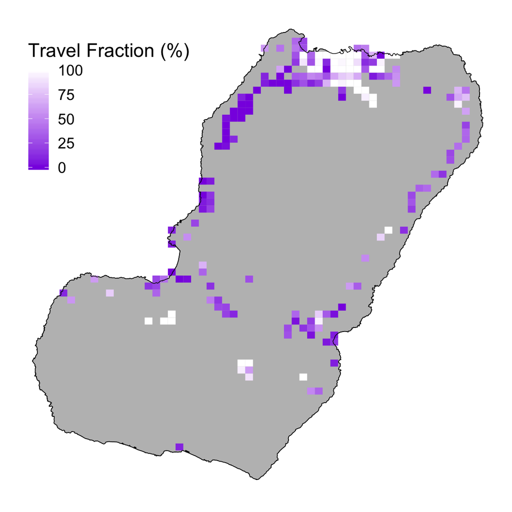

```r
tf.co.map.e <- p2 + geom_polygon(data = plot.data, aes(x = long, y = lat, group = group, fill = 100*tf.co.e), color = NA, size = 0.25) +
  scale_fill_gradient(name="Travel Fraction (%)", low="blueviolet", high="white", limits=c(0, 100)) +
  geom_polygon(data = bioko, aes(x = long, y = lat, group = group), color = "black", fill=NA, size = 0.25) +
  theme(text = element_text(size = 16),
        axis.line=element_blank(), axis.text.x=element_blank(),
        axis.text.y=element_blank(),axis.ticks=element_blank(),
        axis.title.x=element_blank(),
        axis.title.y=element_blank(), panel.background=element_blank(), legend.position=c(0.2, 0.8))
tf.co.map.e
```

```r
#ggsave("tf_co_map_e.pdf", plot = tf.co.map.e)
```

## Figure: LR maps - coestimate, upper, lower

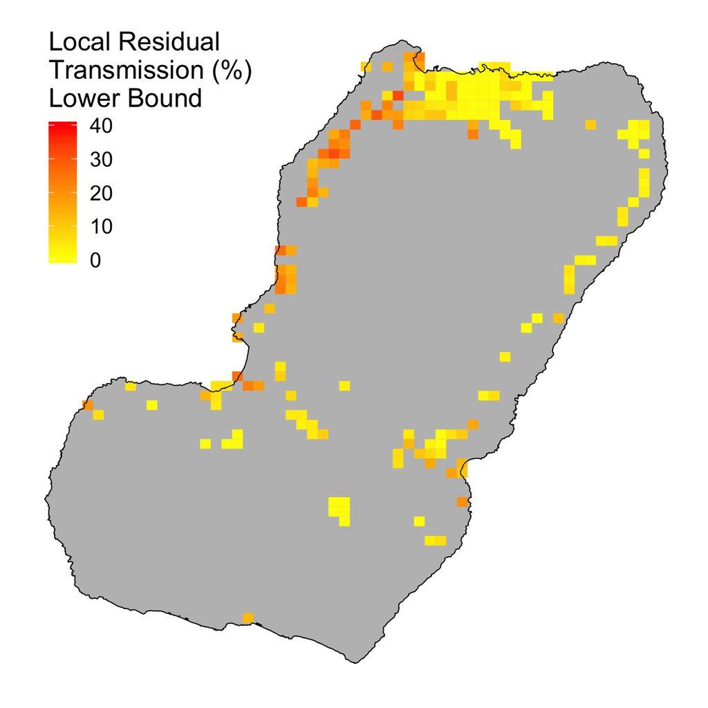

```r
h.upper.map.e <- p2 + geom_polygon(data = plot.data, aes(x = long, y = lat, group = group, fill = 100*h.upper.e/(h.upper.e+1/200)), color = NA, size = 0.25) +
  scale_fill_gradient(name="Local Residual\nTransmission (%)\nLower Bound",
                      low="yellow", high="red", limits=c(0, 40)) +
  geom_polygon(data = bioko, aes(x = long, y = lat, group = group), color = "black", fill=NA, size = 0.25) +
  theme(text = element_text(size = 16),
        axis.line=element_blank(), axis.text.x=element_blank(),
        axis.text.y=element_blank(),axis.ticks=element_blank(),
        axis.title.x=element_blank(),
        axis.title.y=element_blank(), panel.background=element_blank(), legend.position=c(0.2, 0.8))
h.upper.map.e
```

```r
#ggsave("h_upper_map_e.pdf", plot = h.upper.map.e)
```

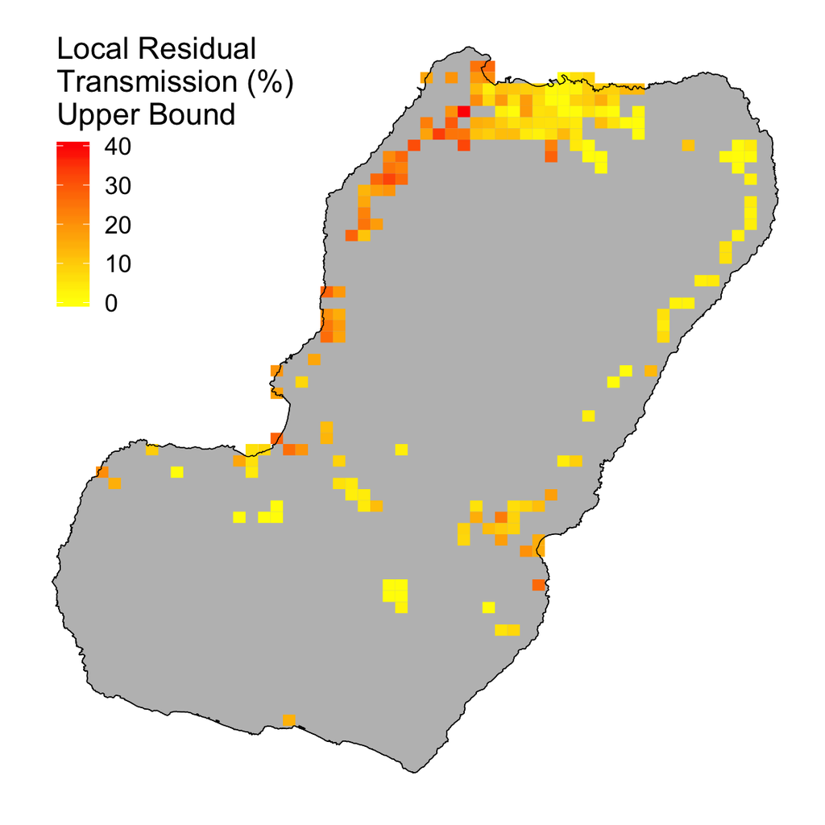

```r
h.lower.map.e <- p2 + geom_polygon(data = plot.data, aes(x = long, y = lat, group = group, fill = 100*h.lower.e/(h.lower.e+1/200)), color = NA, size = 0.25) +
  scale_fill_gradient(name="Local Residual\nTransmission (%)\nUpper Bound",
                      low="yellow", high="red", limits=c(0, 40)) +
  geom_polygon(data = bioko, aes(x = long, y = lat, group = group), color = "black", fill=NA, size = 0.25) +
  theme(text = element_text(size = 16),
        axis.line=element_blank(), axis.text.x=element_blank(),
        axis.text.y=element_blank(),axis.ticks=element_blank(),
        axis.title.x=element_blank(),
        axis.title.y=element_blank(), panel.background=element_blank(), legend.position=c(0.2, 0.8))
h.lower.map.e
```

```r
#ggsave("h_lower_map_e.pdf", plot = h.lower.map.e)
```

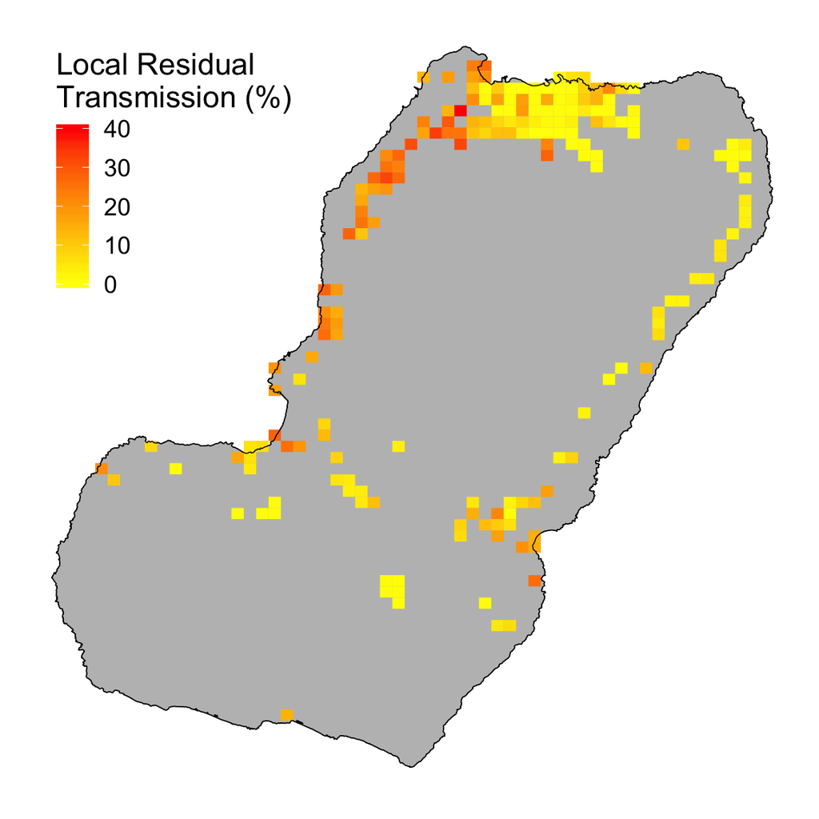

```r
h.co.map.e <- p2 + geom_polygon(data = plot.data, aes(x = long, y = lat, group = group, fill = 100*h.co.e/(h.co.e+1/200)), color = NA, size = 0.25) +
  scale_fill_gradient(name="Local Residual\nTransmission (%)",
                      low="yellow", high="red", limits=c(0, 40)) +
  geom_polygon(data = bioko, aes(x = long, y = lat, group = group), color = "black", fill=NA, size = 0.25) +
  theme(text = element_text(size = 16),
        axis.line=element_blank(), axis.text.x=element_blank(),
        axis.text.y=element_blank(),axis.ticks=element_blank(),
        axis.title.x=element_blank(),
        axis.title.y=element_blank(), panel.background=element_blank(), legend.position=c(0.2, 0.8))
h.co.map.e
```

```r
#ggsave("h_co_map_e.pdf", plot = h.co.map.e)
```

(save plots)

```r
ggsave("tf_lower_map_e.pdf", plot = tf.lower.map.e)
ggsave("tf_upper_map_e.pdf", plot = tf.upper.map.e)
ggsave("tf_co_map_e.pdf", plot = tf.co.map.e)

ggsave("h_upper_map_e.pdf", plot = h.upper.map.e)
ggsave("h_lower_map_e.pdf", plot = h.lower.map.e)
ggsave("h_co_map_e.pdf", plot = h.co.map.e)
```

## Generate Tables

```r
# Coestimate
print("Coestimate")
```

```
## [1] "Coestimate"
```

```r
c(sum(BI[tf.co.e >= 1]$pop)/pop.total, sum(BI[tf.co.e >= 0.8]$pop)/pop.total, sum(BI[tf.co.e >= 0.5]$pop)/pop.total)
```

```
## [1] 0.4835583 0.6721487 0.7476300
```

```r
# Upper
print("Upper")
```

```
## [1] "Upper"
```

```r
c(sum(BI[tf.upper.e >= 1]$pop)/pop.total, sum(BI[tf.upper.e >= 0.8]$pop)/pop.total, sum(BI[tf.upper.e >= 0.5]$pop)/pop.total)
```

```
## [1] 0.5825050 0.7092454 0.8346979
```

```r
# Lower
print("Lower")
```

```
## [1] "Lower"
```

```r
c(sum(BI[tf.lower.e >= 1]$pop)/pop.total, sum(BI[tf.lower.e >= 0.8]$pop)/pop.total, sum(BI[tf.lower.e >= 0.5]$pop)/pop.total)
```

```
## [1] 0.09762337 0.27202036 0.62692631
```

What’s the mean population-weighted local residual transmission

```r
#hist(with(BI, h.co.e/(h.co.e + 1/200)))
#summary(with(BI, h.co.e/(h.co.e + 1/200)))

summary(with(BI, h.co.e/(h.co.e + 1/200)*pop/pop.total))
```

```
##      Min.   1st Qu.    Median      Mean   3rd Qu.      Max.
## 1.170e-07 1.039e-05 3.751e-05 2.625e-04 1.476e-04 1.342e-02
```

```r
summary(with(BI, h.co/(h.co + 1/200)*pop/pop.total))
```

```
##      Min.   1st Qu.    Median      Mean   3rd Qu.      Max.
## 1.170e-07 1.308e-05 4.070e-05 2.641e-04 1.460e-04 1.023e-02
```

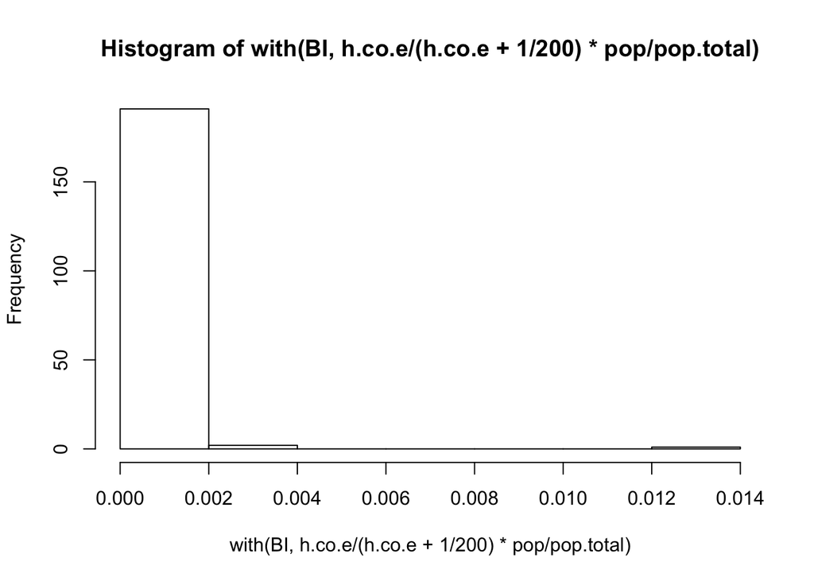

```r
hist(with(BI, h.co.e/(h.co.e + 1/200)*pop/pop.total))
```

## Figure: Eta Histograms

This figure is optional

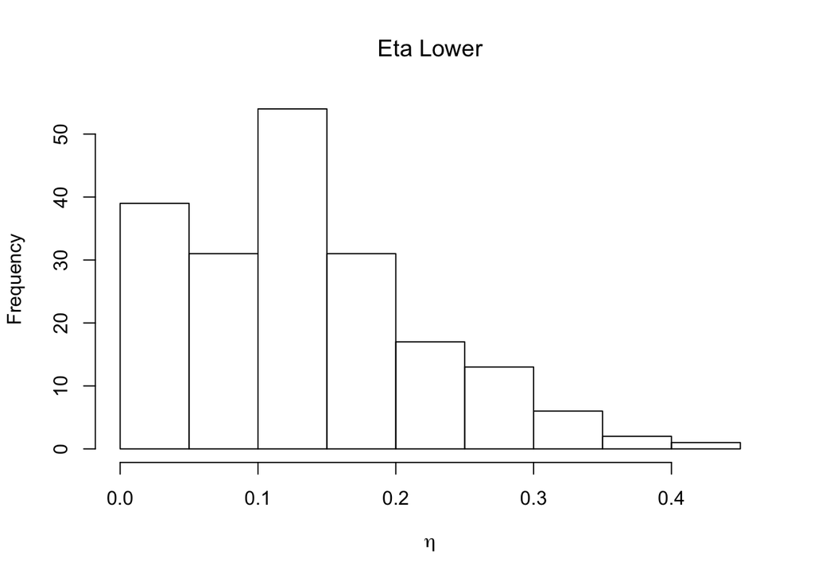

```r
hist(BI$eta.lower.e, main = TeX("Eta Lower"), xlab = TeX("$\\eta$"))
```

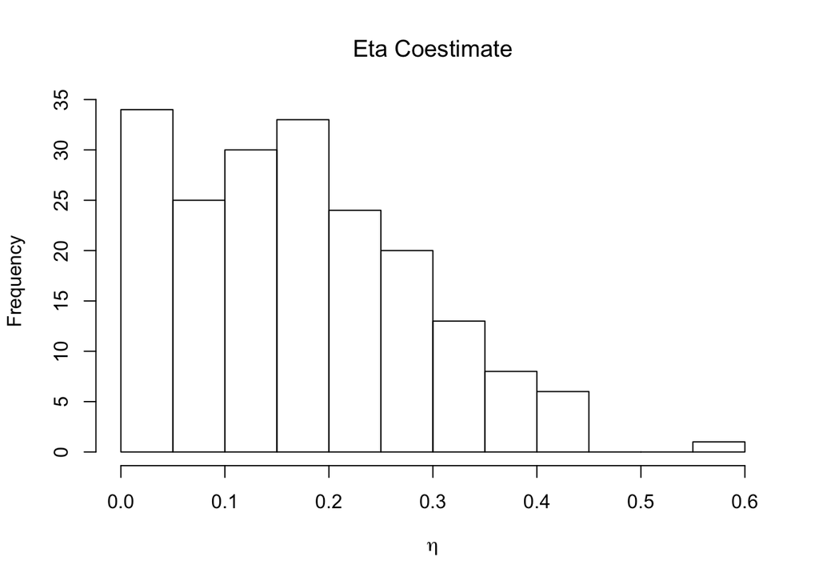

```r
hist(BI$eta.co.e, main = TeX("Eta Coestimate$"), xlab = TeX("$\\eta$"))
```

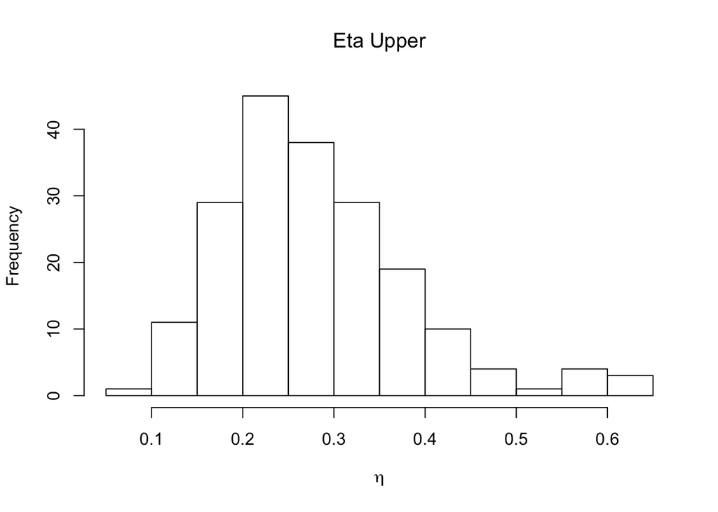

```r
hist(BI$eta.upper.e, main = TeX("Eta Upper"), xlab = TeX("$\\eta$"))
```

## Figure: Travel Fraction Histograms

First, solve for local FOI

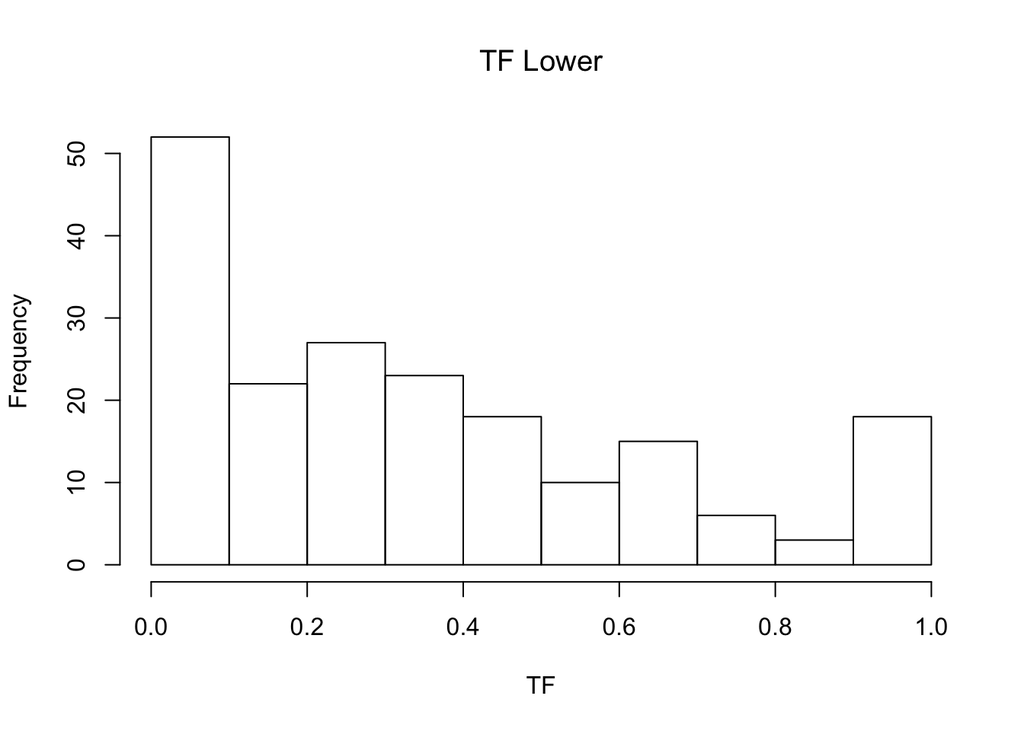

```r
hist(BI$tf.lower.e, main = TeX("TF Lower"), xlab = TeX("$\\TF$"))
```

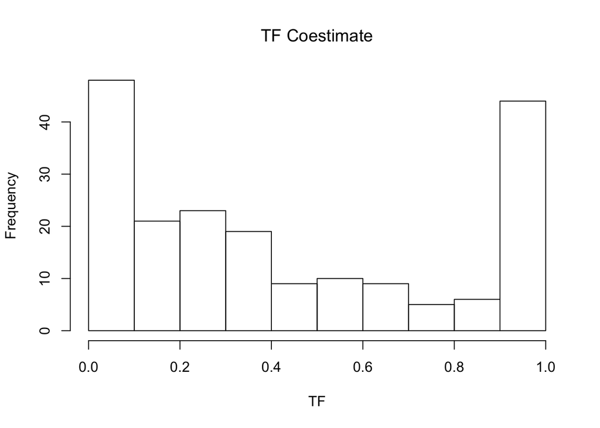

```r
hist(BI$tf.co.e, main = TeX("TF Coestimate$"), xlab = TeX("$\\TF$"))
```

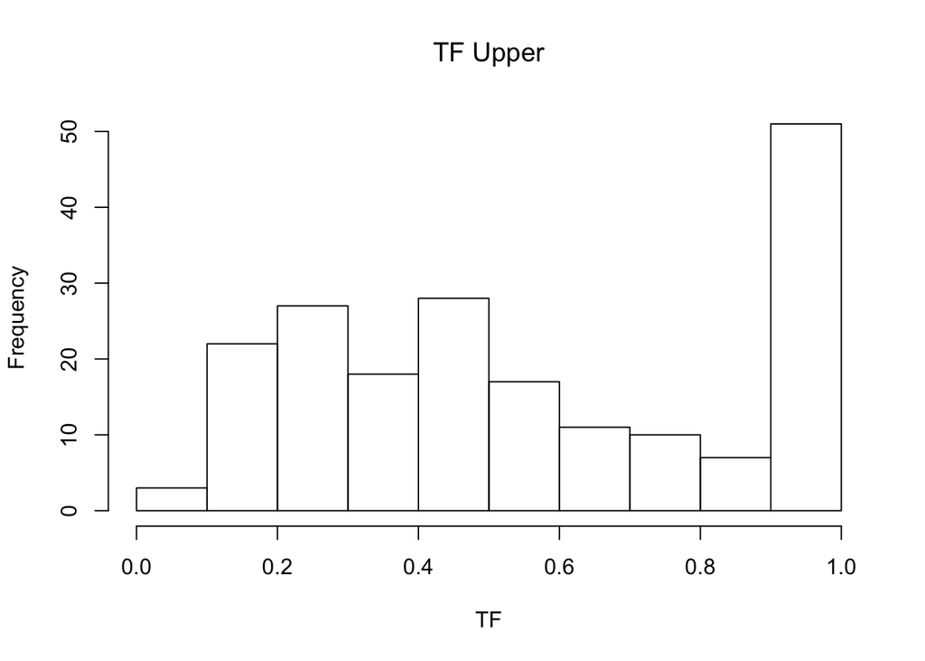

```r
hist(BI$tf.upper.e, main = TeX("TF Upper"), xlab = TeX("$\\TF$"))
```

# Decreasing mean duration of infections

Recompute everything with r = 1/100

```r
# upper
BI$eta.upper.r <- pmax((BI$pre_map),0)*56/100/(1 - exp(-56/100))
BI$h.upper.r <- 0
for (i in 1:194){
  BI$h.upper.r[[i]] <- Travel2h(BI$te_map[[i]], BI$pre_map[[i]], BI$prall_map[[i]], r = 1/100, eta = BI$eta.upper.r[[i]])
}
# lower
BI$eta.lower.r <- pmax((BI$pre_map-BI$prall_map),0)*56/100/(1 - exp(-56/100))
BI$h.lower.r <- 0
for (i in 1:194){
  BI$h.lower.r[[i]] <- Travel2h(BI$te_map[[i]], BI$pre_map[[i]], BI$prall_map[[i]], r = 1/100, eta = BI$eta.lower.r[[i]])
}
# coestimate
BI$h.co.r <- 0
for (i in 1:194){
  BI$h.co.r[[i]] <- Travel2h(BI$te_map[[i]], BI$pre_map[[i]], BI$prall_map[[i]], r = 1/100, hmx = 1)
}
BI$eta.co.r <- 0
for (i in 1:194){
  BI$eta.co.r[[i]] <- Travel2eta(BI$te_map[[i]], BI$pre_map[[i]], h = BI$h.co.r[[i]], r = 1/100)
}
BI$tf.co.r <- 0
for (i in 1:194){
  BI$tf.co.r[[i]] <- Travel2TF(BI$te_map[[i]], BI$pre_map[[i]], BI$prall_map[[i]], h = BI$h.co.r[[i]], r = 1/100, eta = BI$eta.co.r[[i]])
}

## These are in Supplement_BI.R
#plot(with(BI, h.co.e/(h.co.e + 1/200)),
#     with(BI, h.co.r/(h.co.r + 1/100))
#)
#segments(0,0,1,1)

#plot(with(BI, tf.co.e),
#     with(BI, tf.co.r)
#     )
#segments(0,0,1,1)
```

# Last thing: travel heterogeneity?

To do this analysis, ignore local transmission - effectively in the limit where local transmission is unimportant

```r
fac = .5
BI$delta2 = -log(1 - BI$te_map/fac)/56

## See Supplement_BI.R
#plot(with(BI, delta.e*eta.co.e/(delta.e*eta.co.e + r)),
#     with(BI, delta2*eta.co.e/(delta2*eta.co.e + r)*fac))
#segments(0,0,1,1)
```

# Save outputs

```r
holder <- BI[, c("X", "areaId", "to_map", "te_map", "prt_map", "pre_map", "prall_map",
                 "eta.co", "eta.lower", "eta.upper", "eta.co.e", "eta.lower.e", "eta.upper.e",
                 "h.co", "h.lower", "h.upper", "h.co.e", "h.lower.e", "h.upper.e",
                 "tf.co", "tf.lower.e", "tf.upper.e", "tf.co.e", "tf.lower.e", "tf.upper.e",
                 "eta.co.r", "tf.co.r")]

holder$lr.co <- with(BI, h.co/(h.co + 1/200))
holder$lr.lower <- with(BI, h.lower/(h.lower + 1/200))
holder$lr.upper <- with(BI, h.upper/(h.upper + 1/200))
holder$lr.co.e <- with(BI, h.co.e/(h.co.e + 1/200))
holder$lr.lower.e <- with(BI, h.lower.e/(h.lower.e + 1/200))
holder$lr.upper.e <- with(BI, h.upper.e/(h.upper.e + 1/200))

write.csv(holder, "lr_tf_surfaces.csv")
```